# Tutorial 3: Estimation and Confidence Intervals

```python
%reset
import numpy as np
import pandas as pd
import matplotlib.pyplot as plt
import seaborn as sns
import scipy as stats
from scipy import stats
import statsmodels.api as sm
import statsmodels as sm
```

# Confidence Intervals

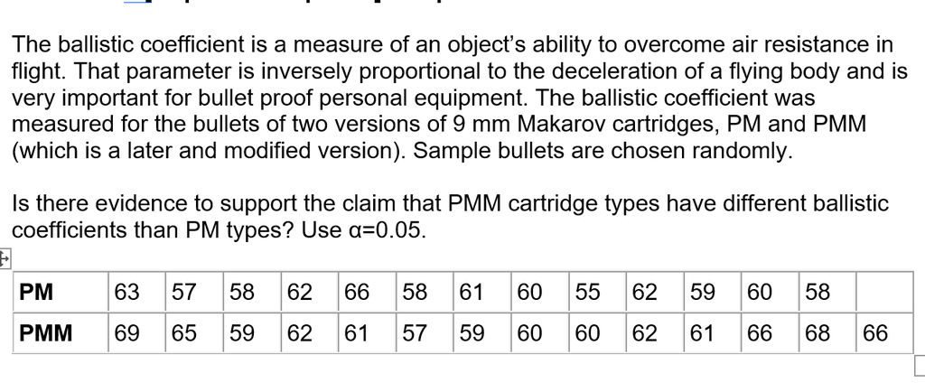

# Part 1

Load in and explore the data: Create graphs and summary statistics to compare versiosn.

You can use pandas to create Series data and then concat to a dataframe.

Or import from .csv file.

```python
A=pd.Series([63.0,57.0,58.0,62.0,66.0,58.0,61.0,60.0,55.0,62.0,59.0,60.0,58.0],name="PM")
B=pd.Series([69.0,65.0,59.0,62.0,61.0,57.0,59.0,60.0,60.0,62.0,61.0,66.0,68.0,66.0],name="PMM")
df=pd.concat([A,B],axis="columns")
df
```

|  | PM | PMM |
| --- | --- | --- |
| 0 | 63.0 | 69.0 |
| 1 | 57.0 | 65.0 |
| 2 | 58.0 | 59.0 |
| 3 | 62.0 | 62.0 |
| 4 | 66.0 | 61.0 |
| 5 | 58.0 | 57.0 |
| 6 | 61.0 | 59.0 |
| 7 | 60.0 | 60.0 |
| 8 | 55.0 | 60.0 |
| 9 | 62.0 | 62.0 |
| 10 | 59.0 | 61.0 |
| 11 | 60.0 | 66.0 |
| 12 | 58.0 | 68.0 |
| 13 | NaN | 66.0 |

```
[Text(46.972222222222214, 0.5, 'Ballistic Coefficient')]
```

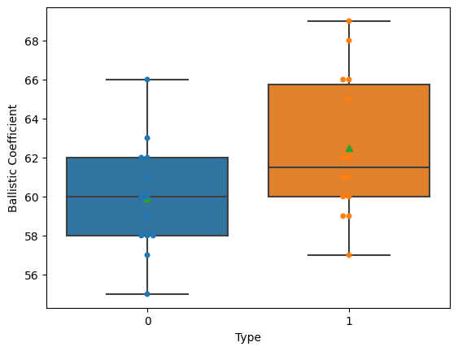

```python
# 1. Plot the data to visualize
ax=sns.boxplot(data=[A, B], showmeans=True)
ax=sns.swarmplot(data=[A, B])
ax.set(xlabel="Type")
ax.set(ylabel="Ballistic Coefficient")
```

```python
# sumamry statistics fo Type A and Type B
df.describe()
```

|  | PM | PMM |
| --- | --- | --- |
| count | 13.000000 | 14.000000 |
| mean | 59.923077 | 62.500000 |
| std | 2.900044 | 3.674235 |
| min | 55.000000 | 57.000000 |
| 25% | 58.000000 | 60.000000 |
| 50% | 60.000000 | 61.500000 |
| 75% | 62.000000 | 65.750000 |
| max | 66.000000 | 69.000000 |

```python
np.std(B, ddof=1)
```

```
3.6742346141747673
```

# Part 2

We want to create 95% confidence intervals for the mean values of the different types?

Review the assumptions needed. Review and defend the assumption of normality for the data for the types.

Let's look at the normal QQ plots

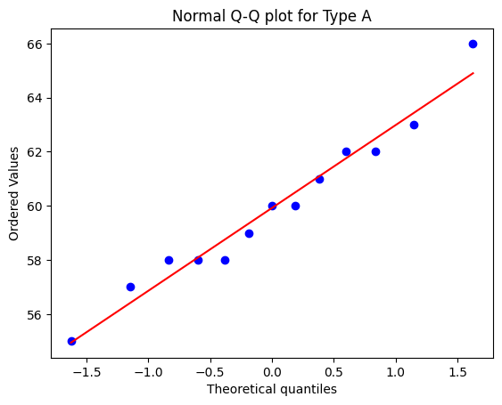

```python
# normal probability plot using scipy models probplot
stats.probplot(A, dist="norm", plot=plt)
plt.title("Normal Q-Q plot for Type A")
plt.show()
```

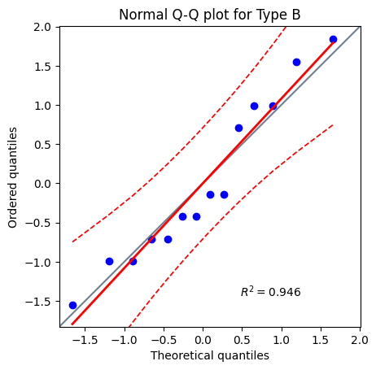

```python
import pingouin as pg

ax = pg.qqplot(df["PMM"], dist='norm', confidence = 0.95)
plt.title("Normal Q-Q plot for Type B")
plt.show()
```

Have you shown that the two samples are normally distributed

# Part 3

Create individual 95% CI for the two groups of differnt types of bullets. Do this by hand and using a t-table and by python.

```python
nA= df["PM"].count() # number in type A
nB= df["PMM"].count() # number in type B
print("The number of observations in the samples are: " + str(nA)+" and " +str(nB))
print("The standard deviation of the sampes are: "+ str(np.std(A,ddof=1))+" and "+ str(np.std(B,ddof=1)))
print("The mean of the samples are: "+ str(np.mean(A)) +" and "+str(np.mean(B)))
print("The variance of the samples are: "+str(np.std(A,ddof=1)**2)+" and "+ str(np.std(B,ddof=1)))
```

[output not shown]

```python
# careful using len call using the dataframe; can use .count()
len(A)
```

```
13
```

```python
len(df["PM"])
```

```
14
```

```python
df["PM"].count()
```

```
13
```

```python
# Find SEM for the two groups
semA= np.std(A,ddof=1) / np.sqrt(nA)
semB= np.std(B,ddof=1) / np.sqrt(nB)
print(f"SEM_A: {semA}")
print(f"SEM_B: {semB}")
```

```
SEM_A: 0.804327545710673
SEM_B: 0.9819805060619657
```

```python
# Find the 95% CI for the two groups
CI_A = stats.t.interval(0.95, df=nA-1, loc=np.mean(A), scale=semA)
CI_B = stats.t.interval(0.95, df=nB-1, loc=np.mean(B), scale=semB)
print(f"95% CI, A: {CI_A[0]} - {CI_A[1]}")
print(f"95% CI, B: {CI_B[0]} - {CI_B[1]}")
```

```
95% CI, A: 58.170597747230815 - 61.675556098923025
95% CI, B: 60.37856009344801 - 64.621439906552
```

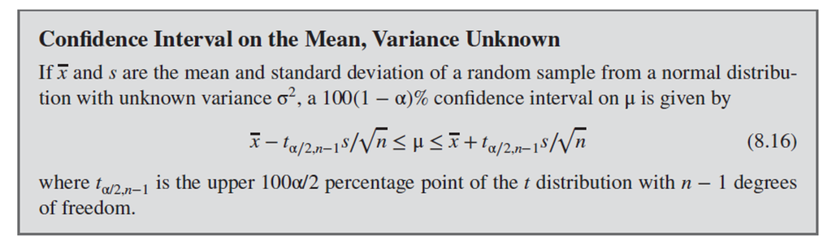

```python
# critcial t-value for 0.025 and n-1
t_crit = stats.t.ppf(1-0.025, nA-1)
print(t_crit)
```

```
2.1788128296634177
```

```python
# lower bound for type a
lowerA= np.mean(A) - t_crit*semA
print(lowerA)
```

```
58.170597747230815
```

```python
# upper bound for type a
upperA= np.mean(A) + t_crit*semA
print(upperA)
```

```
61.675556098923025
```

Use SciPy stats Confidence interval using the t- distirbution https://docs.scipy.org/doc/scipy/reference/generated/scipy.stats.t.html

verify using Python

note: for the stats.t.interval, df=degrees of freedom

loc=mean

scale=standard error of the mean

stats.t.interval(confidence= , df =, loc= , scale= )

```python
stats.t.interval(confidence=0.95,df=((df["PM"].count())-1), loc=np.mean(df["PM"]), scale=semA)
```

```
(58.170597747230815, 61.675556098923025)
```

# Part 4

Graph the Means and Individual 95% Confidence Intervals for the groups.

You cat use seaborn catplot with kind=point to do this easily.

Or seaborn pointplot.

https://seaborn.pydata.org/generated/seaborn.catplot.html https://seaborn.pydata.org/generated/seaborn.pointplot.html

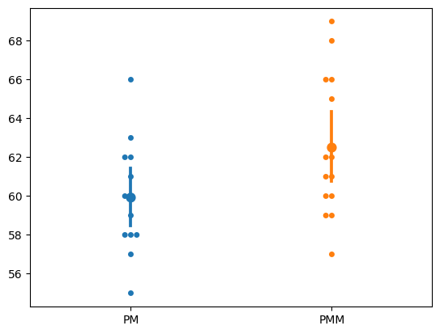

```python
fig, ax = plt.subplots(sharex=True, sharey=True)
sns.pointplot(data=df, estimator='mean', errorbar=('ci', 95), ax=ax, linestyles="None", palette="tab10")
sns.swarmplot(data=df, ax=ax)
plt.show()
```

# Part 5

Create individual 85% CI for the groups and provide a graph with the results. You can just use only python to calculate these and graph the results.

```python
CI_A = stats.t.interval(0.85, df=nA-1, loc=np.mean(A), scale=semA)
CI_B = stats.t.interval(0.85, df=nB-1, loc=np.mean(B), scale=semB)
```

```python
print(f"85% CI, A: {CI_A[0]} - {CI_A[1]}")
print(f"85% CI, B: {CI_B[0]} - {CI_B[1]}")
```

```
85% CI, A: 58.686056150421734 - 61.160097695732105
85% CI, B: 60.99764877082488 - 64.00235122917512
```

```python
t_crit = stats.t.ppf(1-0.075, nA-1)
lowerA= np.mean(A) - t_crit*semA
upperA= np.mean(A) + t_crit*semA
print(lowerA, upperA)
```

```
58.686056150421734 61.160097695732105
```

```python
t_crit = stats.t.ppf(1-0.075, nB-1)
lowerB= np.mean(B) - t_crit*semB
upperB= np.mean(B) + t_crit*semB
print(lowerB, upperB)
```

```
60.99764877082488 64.00235122917512
```

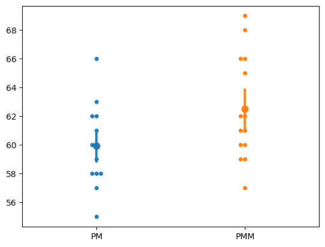

```python
fig, ax = plt.subplots(sharex=True, sharey=True)
sns.pointplot(data=df, estimator='mean', errorbar=('ci', 85), ax=ax, linestyles="None", palette="tab10")
sns.swarmplot(data=df, ax=ax)
plt.show()
```